Business Analytics & Data Science

# Andrew "A.J." Sager

Turning complex data into decisions that matter

M.S. Business Analytics graduate from UC Irvine with hands-on experience building machine learning models, KPI frameworks, and forecasting tools across energy, finance, and tech. Former Division I athlete. Fluent in Python, R, and SQL — and the business language executives actually use.

Get in touch Download resume

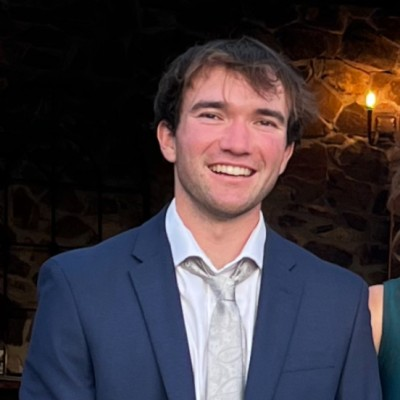

3.88 M.S. GPA

76% ML model accuracy

$200M+ Portfolios supported

D1 Track & cross country

About me

## Analyst. Athlete. Builder.

I'm a data professional with a foundation in applied econometrics, predictive modeling, and financial analysis. My work sits at the intersection of rigorous quantitative methods and clear, stakeholder-ready communication — I build the models *and* write the 72-page reports that explain what they mean.

After earning both my B.S. in Quantitative Economics and my M.S. in Business Analytics from UC Irvine — graduating with honors and earning a spot in Beta Gamma Sigma — I've worked across energy analytics, housing market forecasting, and financial planning. I'm particularly drawn to problems where messy, high-dimensional data hides a story that can actually change what a business does next.

Five years as a Division I track and cross-country athlete gave me a second education: in discipline, in pushing through discomfort, and in what it means to perform under pressure as part of a team. That mindset follows me into every project. In April, I'll be running the Boston Marathon — another box on the list.

When I'm not in the data, I'm out on a trail, casting a line, or hunting down a good cup of coffee.

#### Education

- M.S. Business Analytics — UC Irvine (GPA 3.88)
- B.S. Quantitative Economics — UC Irvine (GPA 3.70)
- Beta Gamma Sigma Honor Society

#### Athletics

Division I Track & Cross Country, UC Irvine (2020–2025). Boston Marathon competitor — April 2026.

#### Outside the office

- Hiking & trail running
- Fishing
- Exploring specialty coffee

Technical skills

## Tools & technologies

#### Programming & machine learning

Python R SQL Pandas NumPy Scikit-learn XGBoost Random Forest PCA Econometric Modeling Time Series NLP

#### Data & visualization

Tableau Power BI Excel ggplot2 MongoDB ETL Pipelines Dashboard Dev

#### AI & development

Generative AI Prompt Engineering RAG Pipelines LLM Integration AI Product QA Flask Streamlit Git / GitHub

#### Business & communication

Stakeholder Reporting Technical Writing RFP Development Agile Workflows Client Presentations Project Management

Work history

## Experience

EcoMetricx

Jan 2026 – Present

Business Analyst

- Built a quantitative KPI scoring rubric to evaluate 48 client programs using PCA to identify statistically significant drivers of program success
- Authored a 72-page analytical report integrating econometric modeling and 30+ stakeholder interviews to produce data-backed strategic recommendations
- Designed and executed structured product testing protocols for an AI chatbot and dashboard, delivering iterative findings to the development team
- Contributed to a successfully won contract through RFP development and client-facing presentations on data science and AI

Schneider Electric

Jan 2025 – Jun 2025

Student Capstone Data Analyst

- Built an end-to-end ML forecasting model across four major California housing markets, handling data procurement, feature engineering, and model selection
- Served as project manager and primary liaison between the graduate analytics team and client stakeholders at Schneider Electric

Sidoxia, LLC

May 2023 – Nov 2023

Financial Planning & Analysis Intern

- Built Excel forecasting models supporting investment decisions for portfolios exceeding $200M
- Automated financial workflows via Morningstar and Yahoo Finance integrations, cutting report prep time by 30%
- Designed 2 predictive investment models; one was adopted into the 2024 portfolio strategy, enhancing risk-adjusted return analysis

Selected work

## Projects

Sports Analytics · ML

### NCAA Tournament Forecasting Model

Regression, decision trees, and XGBoost ensemble predicting March Madness outcomes. Outperformed ESPN's model in 2024 simulation testing.

76% test accuracy vs. 60% industry benchmark

NLP · Flask · RAG

### NLP Restaurant Recommendation Chatbot

Flask-based chatbot using natural language processing, web scraping, and a retrieval-augmented generation pipeline for personalized restaurant discovery.

25+ active users during beta

Sports Science · R

### Division I Force Plate Analytics

Analyzed force plate performance data in R and Excel to optimize training load for collegiate track and field athletes. Contributed to season-best performances in two events.

UC Irvine Track & Field, 2020–2025

NCAA Forecasting Model

## Project visualizations

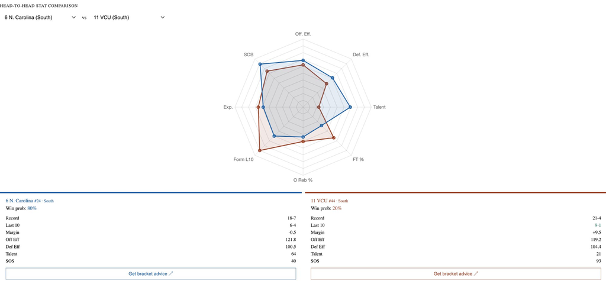

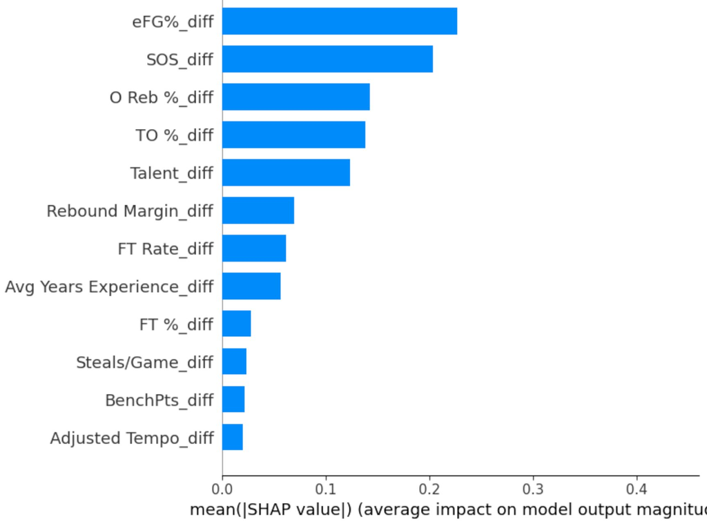

Feature importance / bracket predictions

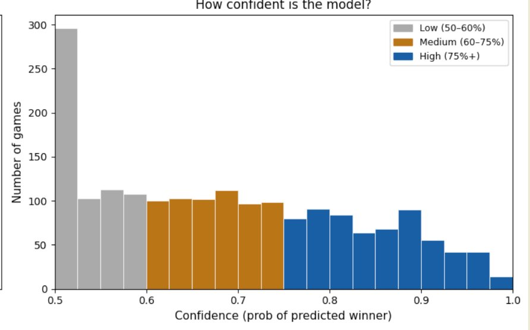

Model confidence distribution by game

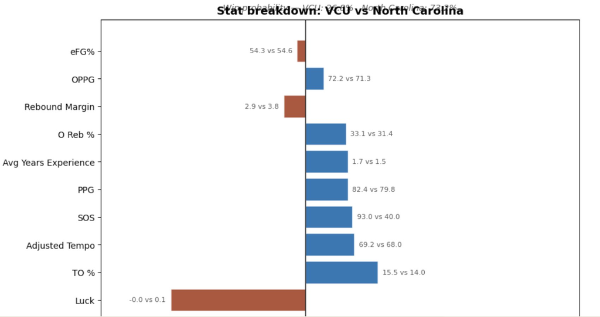

Stat breakdown: VCU vs North Carolina

76% test accuracy — outperforming ESPN's 2024 bracket model

Academic background

## Education

UC Irvine — Paul Merage School of Business

### M.S. Business Analytics

Graduated June 2025 · GPA 3.88

Beta Gamma Sigma Honor Society (Top 20% of class)

UC Irvine — School of Social Sciences

### B.S. Quantitative Economics

Graduated March 2024 · GPA 3.70 / 3.94

Division I Track & Cross Country Athlete

Get in touch

## Let's talk

I'm actively exploring roles in data analytics, business intelligence, financial analysis, and data science. Whether you have a specific opportunity or just want to connect, I'd love to hear from you.

Based in San Diego, CA — open to remote or hybrid.

Send an email

Email [email protected]

LinkedIn linkedin.com/in/aj-sager

GitHub github.com/ajsager21

Phone (619) 733-8952